# FMST_Cement_Manufacturing_Project

## Featurization and Model Tuning Project

## Data Description:

The actual concrete compressive strength (MPa) for a given mixture under a specific age (days) was determined from laboratory. Data is in raw form (not scaled). The data has 8 quantitative input variables, and 1 quantitative output variable, and 1030 instances (observations).

## Domain:

Cement manufacturing

## Context:

Concrete is the most important material in civil engineering. The concrete compressive strength is a highly nonlinear function of age and ingredients. These ingredients include cement, blast furnace slag, fly ash, water, superplasticizer, coarse aggregate, and fine aggregate.

## Attribute Information:

 Cement : measured in kg in a m3 mixture  
 Blast : measured in kg in a m3 mixture  
 Fly ash : measured in kg in a m3 mixture  
 Water : measured in kg in a m3 mixture  
 Superplasticizer : measured in kg in a m3 mixture  
 Coarse Aggregate : measured in kg in a m3 mixture  
 Fine Aggregate : measured in kg in a m3 mixture  
 Age : day (1~365)  
 Concrete compressive strength measured in MPa

## Learning Outcomes:

 Exploratory Data Analysis  
 Building ML models for regression  
 Hyper parameter tuning

## Objective:

Modeling of strength of high performance concrete using Machine Learning

## Steps and tasks:

### 1. Deliverable -1 (Exploratory data quality report reflecting the following) (20 marks)

#### a. Univariate analysis (5 marks)

i. Univariate analysis – data types and description of the independent attributes which should include (name, meaning, range of values observed, central values (mean and median), standard deviation and quartiles, analysis of the body of distributions / tails, missing values, outliers

```python
# Import necessary libraries
import numpy as np
import pandas as pd
import matplotlib.pyplot as plt
%matplotlib inline
import seaborn as sns
sns.set(color_codes=True)
import warnings
warnings.filterwarnings("ignore")
```

```python
# Read the data into dataframe
fmst_df=pd.read_csv("concrete (1).csv")
```

```python
df=fmst_df.copy()
df.head()
```

|  | cement | slag | ash | water | superplastic | coarseagg | fineagg | age | strength |
| --- | --- | --- | --- | --- | --- | --- | --- | --- | --- |
| 0 | 141.3 | 212.0 | 0.0 | 203.5 | 0.0 | 971.8 | 748.5 | 28 | 29.89 |
| 1 | 168.9 | 42.2 | 124.3 | 158.3 | 10.8 | 1080.8 | 796.2 | 14 | 23.51 |
| 2 | 250.0 | 0.0 | 95.7 | 187.4 | 5.5 | 956.9 | 861.2 | 28 | 29.22 |
| 3 | 266.0 | 114.0 | 0.0 | 228.0 | 0.0 | 932.0 | 670.0 | 28 | 45.85 |
| 4 | 154.8 | 183.4 | 0.0 | 193.3 | 9.1 | 1047.4 | 696.7 | 28 | 18.29 |

```python
# To get the shape (rows x columns) of the dataset
df.shape
```

```
(1030, 9)
```

```python
# Below gives row count and attribute data-type info
df.info()
```

```
<class 'pandas.core.frame.DataFrame'>
RangeIndex: 1030 entries, 0 to 1029
Data columns (total 9 columns):
cement          1030 non-null float64
slag            1030 non-null float64
ash             1030 non-null float64
water           1030 non-null float64
superplastic    1030 non-null float64
coarseagg       1030 non-null float64
fineagg         1030 non-null float64
age             1030 non-null int64
strength        1030 non-null float64
dtypes: float64(8), int64(1)
memory usage: 72.5 KB
```

```python
# Below gives complete information about data.
# Provides 5 point summary for numerical attributes[Mininum, First Quantile[25%], Median[50%], Third Quantile[75%], Max].
df.describe(include='all').T
```

|  | count | mean | std | min | 25% | 50% | 75% | max |
| --- | --- | --- | --- | --- | --- | --- | --- | --- |
| cement | 1030.0 | 281.167864 | 104.506364 | 102.00 | 192.375 | 272.900 | 350.000 | 540.0 |
| slag | 1030.0 | 73.895825 | 86.279342 | 0.00 | 0.000 | 22.000 | 142.950 | 359.4 |
| ash | 1030.0 | 54.188350 | 63.997004 | 0.00 | 0.000 | 0.000 | 118.300 | 200.1 |
| water | 1030.0 | 181.567282 | 21.354219 | 121.80 | 164.900 | 185.000 | 192.000 | 247.0 |
| superplastic | 1030.0 | 6.204660 | 5.973841 | 0.00 | 0.000 | 6.400 | 10.200 | 32.2 |
| coarseagg | 1030.0 | 972.918932 | 77.753954 | 801.00 | 932.000 | 968.000 | 1029.400 | 1145.0 |
| fineagg | 1030.0 | 773.580485 | 80.175980 | 594.00 | 730.950 | 779.500 | 824.000 | 992.6 |
| age | 1030.0 | 45.662136 | 63.169912 | 1.00 | 7.000 | 28.000 | 56.000 | 365.0 |
| strength | 1030.0 | 35.817961 | 16.705742 | 2.33 | 23.710 | 34.445 | 46.135 | 82.6 |

```python
# Get skewness of features
df.skew()
```

```
cement          0.509481
slag            0.800717
ash             0.537354
water           0.074628
superplastic    0.907203
coarseagg      -0.040220
fineagg        -0.253010
age             3.269177
strength        0.416977
dtype: float64
```

```python
# To check if any missing(NaN) values are present
df.isna().values.any()
```

```
False
```

```python
# Function for creating histogram and box-plot side by side for continuous variables
# Histogram plot is to help in understanding the distribution of the feature
# Box-plot is to see the data spread across quantiles and also to identify outliers if any
def numerical_feature_plot(feature):
    fig,ax=plt.subplots(nrows=1,ncols=2,figsize=(14,6))
    sns.distplot(df[feature],ax=ax[0])
    ax[0].set_title("Histogram of "+feature)
    sns.boxplot(y=df[feature],ax=ax[1])
    ax[1].set_title("Boxplot of "+feature)
```

```python
def numerical_feature_analysis(feature):
    feature_min=df[feature].min()
    feature_max=df[feature].max()
    feature_q1=np.quantile(df[feature],0.25)
    feature_q3=np.quantile(df[feature],0.75)
    feature_IQR=(feature_q3-feature_q1)
    feature_lower_whisker=feature_q1-(feature_IQR*1.5)
    feature_upper_whisker=feature_q3+(feature_IQR*1.5)

    print("Feature: ",feature)
    if (feature_lower_whisker<=feature_min) and (feature_upper_whisker>=feature_max):
        print("No outliers.")
    else:
        if (feature_upper_whisker<feature_max):
            print("Outliers are present in maximum. ",feature," above ",round(feature_upper_whisker,2)," are outliers and total are ",df[df[feature]>feature_upper_whisker][feature].count())
        if (feature_lower_whisker>feature_min):
            print("Outliers are present in minimum. ",feature," below ",round(feature_lower_whisker,2)," are outliers and total are ",df[df[feature]<feature_lower_whisker][feature].count())

    print("----------------------------------------------------------------------------------------------")
```

```python
numerical_feature_list=list(df.select_dtypes(exclude='object').columns)
categorical_feature_list=list(df.select_dtypes(include='object').columns)

print("Numerical Features: ",numerical_feature_list)
print("Categorical Features: ",categorical_feature_list)
```

```
Numerical Features:  ['cement', 'slag', 'ash', 'water', 'superplastic', 'coarseagg', 'fineagg', 'age', 'strength']
Categorical Features:  []
```

```
Feature:  cement
No outliers.
----------------------------------------------------------------------------------------------
Feature:  slag
Outliers are present in maximum.  slag  above  357.38  are outliers and total are  2
----------------------------------------------------------------------------------------------
Feature:  ash
No outliers.
----------------------------------------------------------------------------------------------
Feature:  water
Outliers are present in maximum.  water  above  232.65  are outliers and total are  4
Outliers are present in minimum.  water  below  124.25  are outliers and total are  5
----------------------------------------------------------------------------------------------
Feature:  superplastic
Outliers are present in maximum.  superplastic  above  25.5  are outliers and total are  10
----------------------------------------------------------------------------------------------
Feature:  coarseagg
No outliers.
----------------------------------------------------------------------------------------------
Feature:  fineagg
Outliers are present in maximum.  fineagg  above  963.58  are outliers and total are  5
----------------------------------------------------------------------------------------------
Feature:  age
Outliers are present in maximum.  age  above  129.5  are outliers and total are  59
----------------------------------------------------------------------------------------------
Feature:  strength
Outliers are present in maximum.  strength  above  79.77  are outliers and total are  4
----------------------------------------------------------------------------------------------
```

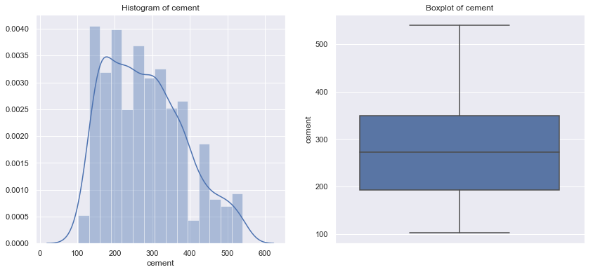

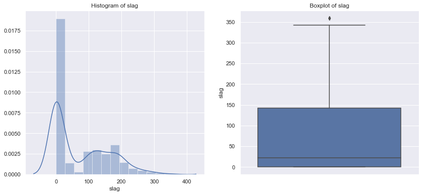

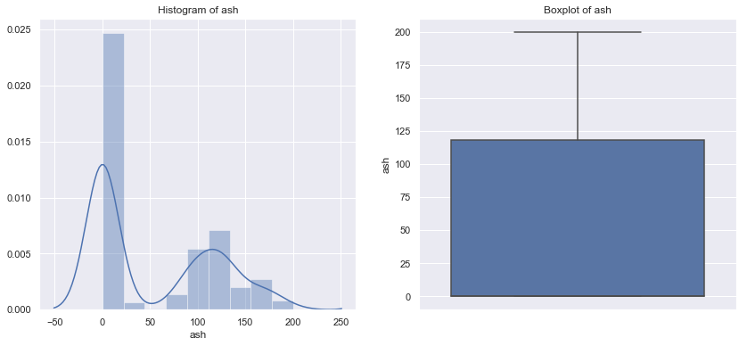

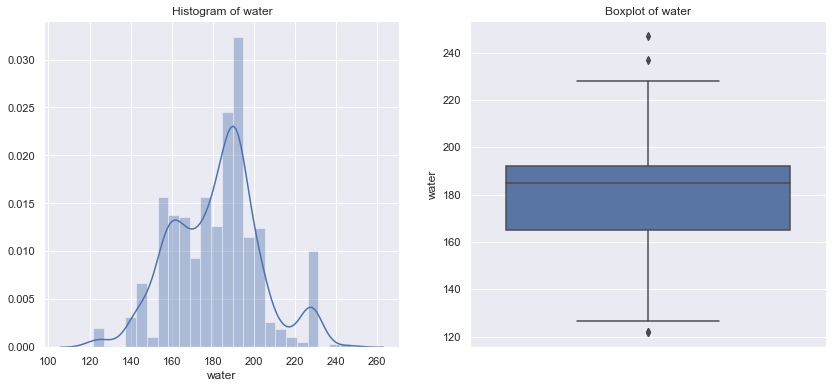

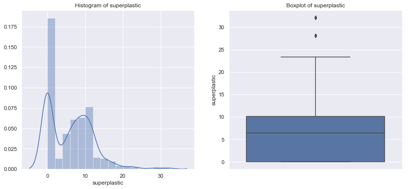

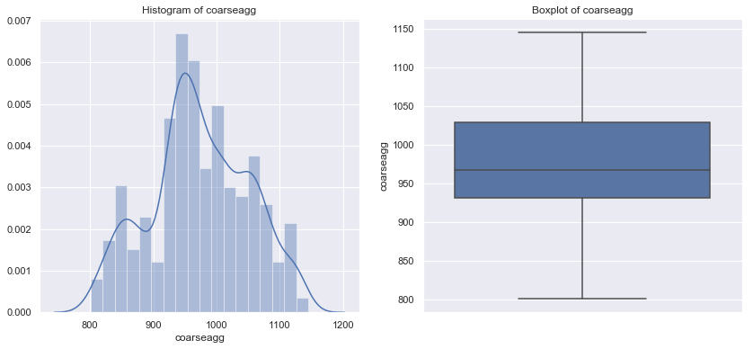

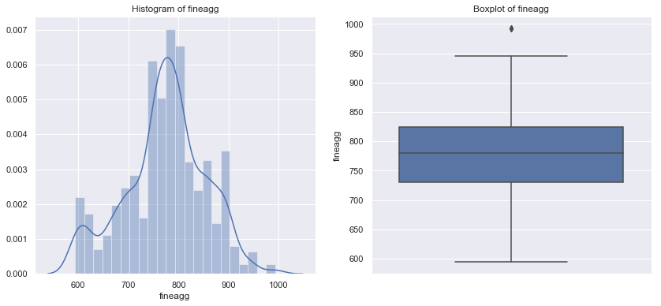

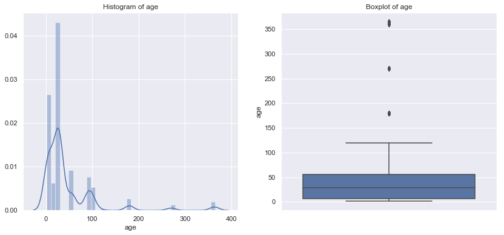

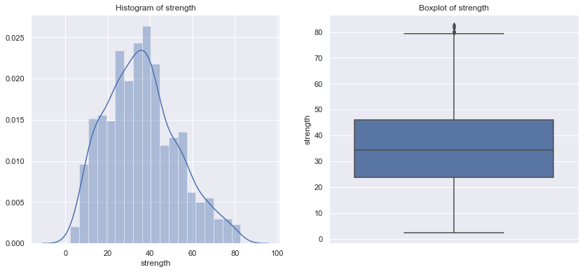

```python
for i in numerical_feature_list:
    numerical_feature_plot(i)
    numerical_feature_analysis(i)
```

#### Observations:

#### cement:

Though not perfect, data looks like normally distributed. Spread seems to deviate more in 4th quartile.

#### ash:

Around 50% of the data is having value 0. And rest other data forms a good guassian distribution.

#### water:

This seems like a mix of 3 gaussians with their peaks widely seperated.

#### superplastic:

Around 25% of the data is having value 0. And rest other data forms a gaussian with right skewness.

#### coarseagg:

This looks like a mix of 2-3 gaussians with their peaks at different values and bit widely seperated.

#### fineagg:

This looks like a mix of 3 gaussians having first 2 peaks widely seperated and distance between further two is close.

#### age:

Though the distribution looks like it has 5 different range values, around 75% of the data is within age 56 days.

#### strength:

Out of all features this has a very good gaussian distribution.

#### Note: As per the data and all analysis above, it looks that data doesn't have any missing values. Its a regression model because target for this dataset is feature 'strength' which is a continuous variable and rest other features can be considered as predictors for now.

#### b. Multivariate analysis (5 marks)

i. Bi-variate analysis between the predictor variables and between the predictor variables and target column. Comment on your findings in terms of their relationship and degree of relation if any. Presence of leverage points. Visualize the analysis using boxplots and pair plots, histograms or density curves. Select the most appropriate attributes

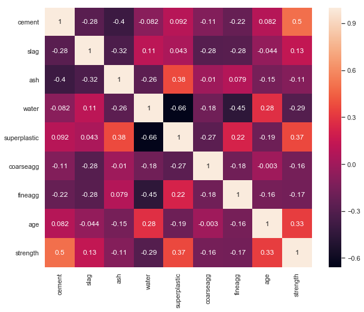

```python
# For continuous variables, Correlation with Heatmap serves as starting point
plt.figure(figsize=(10,8))
sns.heatmap(df.corr(),annot=True)
```

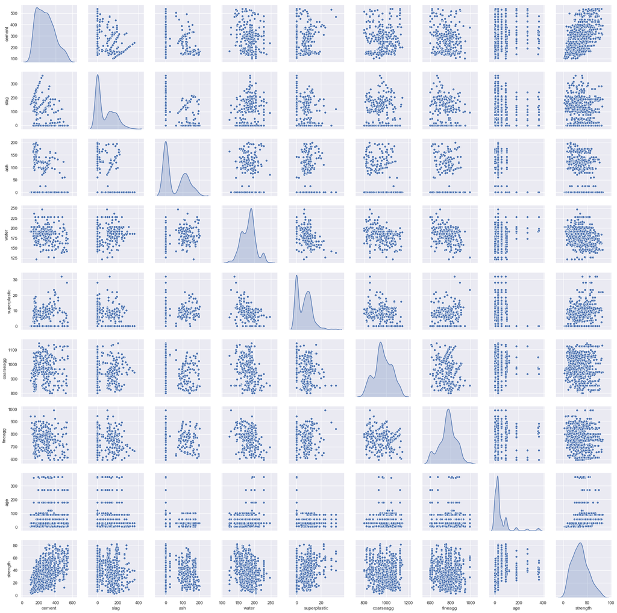

```python
sns.pairplot(data=df,diag_kind='kde')
# Saving the pairplot, so I can open it seperately and see the details better by zooming
plt.savefig("FMST_Pairplot.png")
```

cement vs slag:  
Scatter plot looks like 3 clustered distributions.  
a. cement vs slag [<100] - No relationship between features  
b. cement vs slag [>=100 to <200] - Linear relation with slope around 1.  
c. cement vs slag [>=200] - Linear relation with high slope value.

slag vs ash:  
This looks like mix of 3 clustered distributions.

cement vs strength:  
This is somewhat in +ve linear relation when compared with other features.

water vs strength:  
This seems somewhat in -ve linear relation.

water vs fineagg & water vs superplastic:  
Both relations are somewhat is -ve linear relation.

Other than above, couldnt see much of relations between the features.

#### c. Pick one strategy to address the presence of outliers and missing values and perform necessary imputation (10 marks)

#### Outlier Treatment:

Already outliers are captured in Univariate analysis through IQR approach.  
After carefully going through outliers, it looks that capping process is better in this case. The reason being strength values of upper/lower whisker are almost in same range as outliers for each predictors.

Note: Since here we are doing capping process, it can be done before splitting the data into train and test. The reason being, impact is very minimal if we do this activity befor or after the data split.

```python
def outlier_handler(feature):
    feature_min=df[feature].min()
    feature_max=df[feature].max()
    feature_q1=np.quantile(df[feature],0.25)
    feature_q3=np.quantile(df[feature],0.75)
    feature_IQR=(feature_q3-feature_q1)
    feature_lower_whisker=feature_q1-(feature_IQR*1.5)
    feature_upper_whisker=feature_q3+(feature_IQR*1.5)
    print(feature)
    if (feature_lower_whisker<=feature_min) and (feature_upper_whisker>=feature_max):
        print("No outliers.")
    else:
        print("changing outliers' value using capping.")
        if (feature_upper_whisker<feature_max):
            # Capping is done to replace outliers.
            df.loc[df[feature]>feature_upper_whisker ,feature] =feature_upper_whisker
        if (feature_lower_whisker>feature_min):
            # Capping is done to replace outliers.
            df.loc[df[feature]<feature_lower_whisker,feature] =feature_lower_whisker
```

```python
for i in numerical_feature_list:
    outlier_handler(i)
```

```
cement
No outliers.
slag
changing outliers' value using capping.
ash
No outliers.
water
changing outliers' value using capping.
superplastic
changing outliers' value using capping.
coarseagg
No outliers.
fineagg
changing outliers' value using capping.
age
changing outliers' value using capping.
strength
changing outliers' value using capping.
```

#### Missing values

In Univariate analysis, we observed that there are no missing values in the dataset. So no further imputation is needed.

### 2. Deliverable -2 (Feature Engineering techniques) (15 marks)

#### a. Identify opportunities (if any) to create a composite feature, drop a feature etc. (5 marks)

#### Feature Selection

As per above Multivariate analysis, below features are not that helpful[very weak predictors]:

slag  
ash  
coarseagg  
fineagg

Note: Correlation <0.2 is considered as very weak predictors. Hence above mentioned features can be dropped from building model.

#### b. Decide on complexity of the model, should it be simple linear model in terms of parameters or would a quadratic or higher degree help (5 marks)

This definitely can not be fit in a simple linear model. Reason being of very low correlation between Target and Independent features. Probably Tree based Algorithms or Polynomial Regressions can help in better prediction.

#### c. Explore for gaussians. If data is likely to be a mix of gaussians, explore individual clusters and present your findings in terms of the independent attributes and their suitability to predict strength (5 marks)

By looking at Univariate analysis, many features has more than one gaussian. So there can be a chance that data is mix of multiple clusters. And may be if we build model for each cluster it can give a better result.  
Let us do clustering and see.

```python
from sklearn.cluster import KMeans
from sklearn.model_selection import train_test_split
from sklearn.preprocessing import StandardScaler
```

```python
# Scaling using Z-transformation
sc=StandardScaler()
sc=sc.fit(df)
df_cluster=pd.DataFrame(data=sc.transform(df),columns=df.columns)
```

```python
df_cluster.describe().T
```

|  | count | mean | std | min | 25% | 50% | 75% | max |
| --- | --- | --- | --- | --- | --- | --- | --- | --- |
| cement | 1030.0 | -3.858833e-16 | 1.000486 | -1.715253 | -0.850053 | -0.079152 | 0.658961 | 2.477915 |
| slag | 1030.0 | 3.915961e-16 | 1.000486 | -0.856971 | -0.856971 | -0.601823 | 0.800911 | 3.287734 |
| ash | 1030.0 | 3.634633e-16 | 1.000486 | -0.847144 | -0.847144 | -0.847144 | 1.002278 | 2.281084 |
| water | 1030.0 | 4.909773e-16 | 1.000486 | -2.700633 | -0.784513 | 0.162941 | 0.492900 | 2.409020 |
| superplastic | 1030.0 | -1.237414e-16 | 1.000486 | -1.061968 | -1.061968 | 0.041549 | 0.696762 | 3.334858 |
| coarseagg | 1030.0 | 7.116206e-16 | 1.000486 | -2.212138 | -0.526517 | -0.063294 | 0.726761 | 2.214224 |
| fineagg | 1030.0 | 1.200334e-15 | 1.000486 | -2.249277 | -0.532607 | 0.075967 | 0.633775 | 2.383350 |
| age | 1030.0 | -2.931851e-16 | 1.000486 | -1.036502 | -0.868740 | -0.281572 | 0.501319 | 2.556406 |
| strength | 1030.0 | -1.744020e-16 | 1.000486 | -2.006952 | -0.725434 | -0.081978 | 0.618721 | 2.634953 |

```python
# Ideally kMeans should be fit on only training data set. Since we have very low volume data, lets consider entire dataset.
k=15
wcss_lst=[]
for i in range(1,k):
    km_model=KMeans(n_clusters=i,n_jobs=-1,random_state=1)
    km_model=km_model.fit(df_cluster)
    wcss_lst.append(km_model.inertia_)
```

```python
wcss_lst
```

```
[9270.0,
 7590.117077653289,
 6375.593399195142,
 5569.991259700093,
 4970.536567737703,
 4507.792764168061,
 4223.24692400283,
 3946.9857809683917,
 3696.209546593732,
 3520.5460677736996,
 3329.608833372989,
 3147.787388451904,
 3000.2159310877473,
 2889.0477483973746]
```

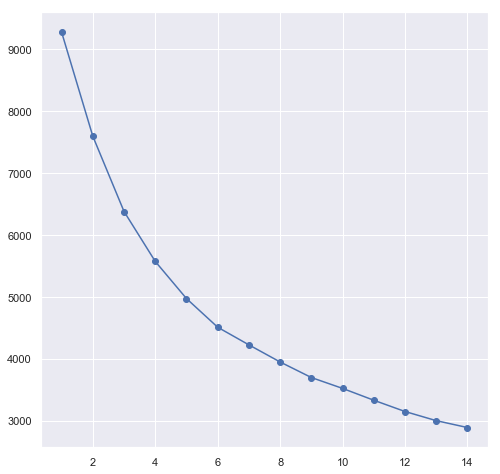

```python
plt.figure(figsize=(8,8))
plt.plot(range(1,k),wcss_lst,marker='o')
```

K=6 seems to give better clustering.

```python
k=6
km_model=KMeans(n_clusters=k,n_jobs=-1,random_state=1)
km_model=km_model.fit(df_cluster)
df_cluster['group']=km_model.labels_
```

```python
df_cluster.groupby(by='group').mean()
```

| group | cement | slag | ash | water | superplastic | coarseagg | fineagg | age | strength |
| --- | --- | --- | --- | --- | --- | --- | --- | --- | --- |
| 0 | 1.024787 | 0.461271 | -0.501022 | -0.987227 | 1.128731 | -0.627702 | 0.218251 | -0.108953 | 1.198202 |
| 1 | -0.836818 | 1.394974 | -0.825980 | 0.507218 | -0.679724 | -0.014671 | -0.177914 | -0.414034 | -0.656721 |
| 2 | -0.604224 | -0.653721 | 1.111552 | -0.622622 | 0.418555 | 0.605000 | 0.419097 | 0.012420 | -0.172243 |
| 3 | -0.424058 | 0.178500 | 1.094908 | 0.586999 | 0.406578 | -1.194637 | -0.341996 | -0.329415 | -0.243863 |
| 4 | 0.674447 | -0.842930 | -0.835444 | 0.400820 | -1.011542 | 0.723305 | -0.044700 | -0.599160 | -0.587904 |
| 5 | 0.488835 | -0.194550 | -0.823136 | 1.196799 | -1.021787 | 0.018851 | -0.665691 | 1.993579 | 0.455443 |

[output not shown]

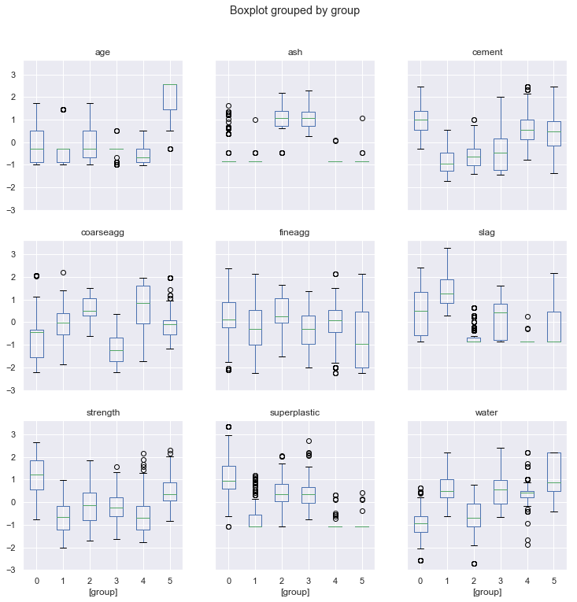

```python
df_cluster.boxplot(by='group',figsize=(12,12))
```

[output not shown]

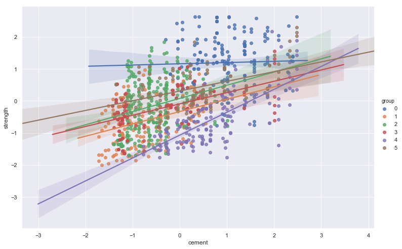

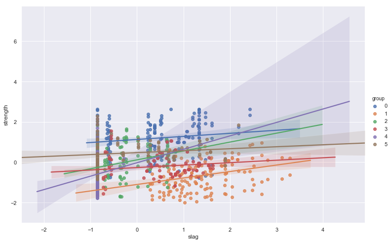

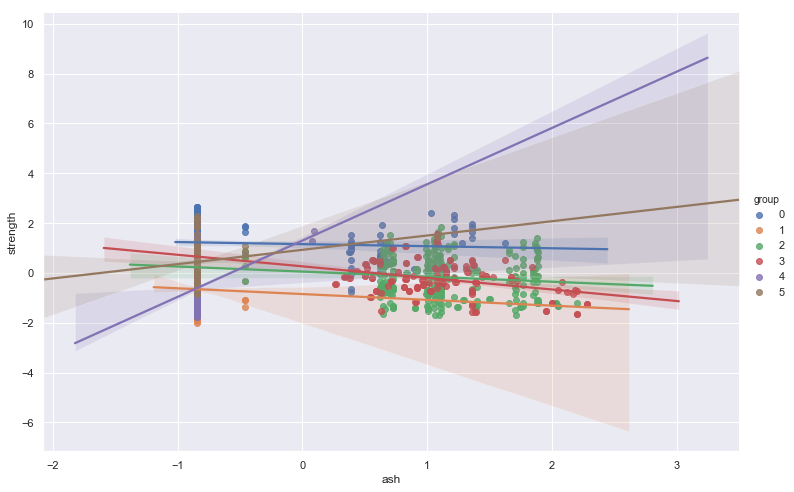

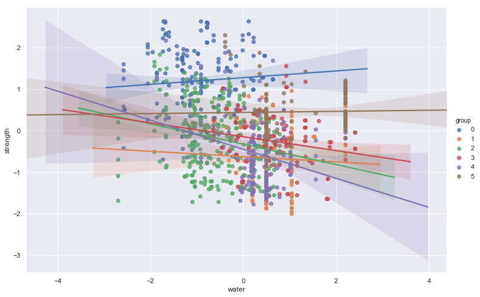

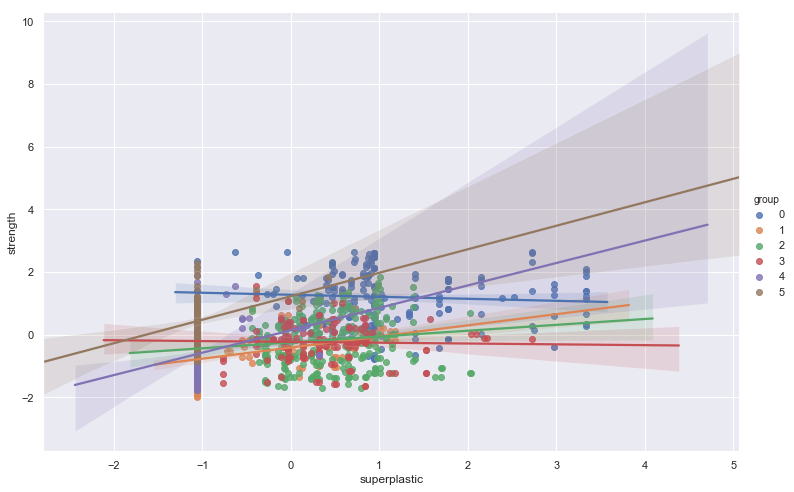

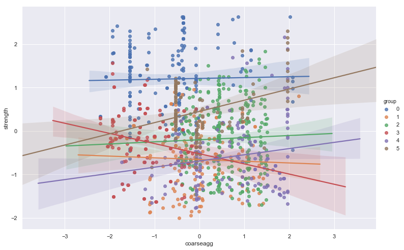

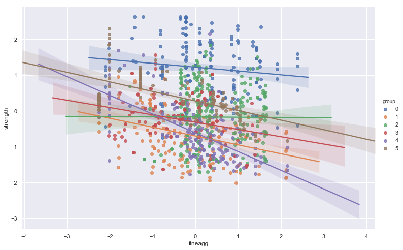

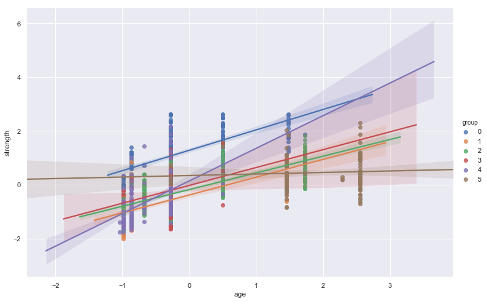

```python
# Trying to get a LR models for each group
for i in numerical_feature_list:
    if i!='strength':
        sns.lmplot(x=i,y='strength',hue='group',data=df_cluster,height=7,aspect=1.5)
```

#### Observations:

#### cement vs strength:

Group 0: Very minimal variation[Horizontal line] , indicating the cement is not a good predictor for strength.  
Group 1,2,3: cement is a weak predictor and variation of the data for these groups across the regression is in heteroscedasticity.  
Group 4: Having good variation w.r.t. strength

#### slag vs strength:

Group 0,3,5: Very minimal variation[Horizontal line] , indicating the slag is not a good predictor for strength.  
Group 1: slag is a weak predictor.  
Group 2,4: Having good variation w.r.t. strength but is having heteroscedasticity.

#### ash vs strength:

Group 0,1,2: Very minimal variation[Horizontal line] , indicating the ash is not a good predictor for strength.  
Group 3: ash is a weak predictor.  
Group 4,5: Having good variation w.r.t. strength but is having heteroscedasticity.

#### water vs strength:

Group 0,1,5: Very minimal variation[Horizontal line] , indicating the water is not a good predictor for strength.  
Group 2,3: water is a weak predictor.  
Group 4: Having good variation w.r.t. strength but is having heteroscedasticity.

#### superplastic vs strength:

Group 0,2,3: Very minimal variation[Horizontal line] , indicating the superplastic is not a good predictor for strength.  
Group 1: superplastic is a weak predictor.  
Group 4,5: Having good variation w.r.t. strength but is having heteroscedasticity.

#### coarseagg vs strength:

Group 0,1,2: Very minimal variation[Horizontal line] , indicating the coarseagg is not a good predictor for strength.  
Group 4: coarseagg is a weak predictor.  
Group 3,5: Having good variation w.r.t. strength but is having heteroscedasticity.

#### fineagg vs strength:

Group 0,2: Very minimal variation[Horizontal line] , indicating the fineagg is not a good predictor for strength.  
Group 3,5: fineagg is a weak predictor.  
Group 1,4: Having good variation w.r.t. strength and is having less amount of heteroscedasticity.

#### age vs strength:

Group 5: Very minimal variation[Horizontal line] , indicating the age is not a good predictor for strength.  
Group 0,1,2,3,4: Having good variation w.r.t. strength. But for Groups 3 and 4,heteroscedasticity is more.

#### Conclusion:

Above clearly states that all features are not equally important for all groups. Hence a single linear model for the entire dataset wouldn't work.  
Even there are problems with linear models seperately built for each group because of too much heteroscedasticity.

Heteroscedasticity can create problems for Polynomial regression as well and also considering the low volume of dataset its better not to go for Polynomial Regression. Because it can lead to curse of dimensionality.

In this case, its better if we rely on Tree based algorithms which can handle these kind of datasets as trees splits happen in ranges for continuous features.

### 3. Deliverable -3 (create the model ) ( 15 marks)

#### a. Obtain feature importance for the individual features and present your findings

#### Strategy:

1. Build simple linear model with all available features.
2. Build LR model with manual selection.
3. Build Decission Tree Regressor model with all available features.
4. Build rest other Tree based models which can help in understanding initial accuracies without tunning.

Note: Above can help us to get the feature importance and also accuracies from base models.

```python
X =df[['cement', 'slag', 'ash', 'water', 'superplastic', 'coarseagg', 'fineagg', 'age']]
y= df[['strength']]
```

```python
# Split the dataset into train and test
X_train,X_test,y_train,y_test=train_test_split(X,y,test_size=0.3,random_state=1)
```

```python
# Scaling using Z-transformation
sc=StandardScaler()
sc=sc.fit(X_train)
X_train=pd.DataFrame(data=sc.transform(X_train),columns=X_train.columns)
X_test=pd.DataFrame(data=sc.transform(X_test),columns=X_test.columns)
```

```python
from sklearn.metrics import r2_score,mean_squared_error
from sklearn.model_selection import RepeatedKFold
```

```python
# Creating a function for Adjusted R^2 score
def adj_rsquared(r2_score,no_of_coef,sample_size):
    return (1-((1-r2_score)*(sample_size-1)/(sample_size-no_of_coef-1)))
```

```python
# Capture results of differents models
model_results=[]

# Creating a common function which can help in storing the results of each model
def regression_model(model,model_name=None,X_train= X_train,X_test= X_test):
    if model_name is None:
        model_name=model.__class__.__name__
    model=model.fit(X_train,y_train)
    k=len(X_train.columns)
    n=X_test.shape[0]
    y_test_pred=model.predict(X_test)
    test_r2_score=r2_score(y_test,y_test_pred)
    test_adj_r2_score=adj_rsquared(test_r2_score,k,n)
    test_mean_squared_error =mean_squared_error(y_test,y_test_pred)
    print("Test results for ",model_name,":")
    print("Mean square Error:",test_mean_squared_error)
    print("R2 score:",test_r2_score)
    print("Adjusted R2 score:",test_adj_r2_score)
    # model_results.append({model_name:[model,np.round(test_r2_score,2),np.round(adj_r2_score,2)]})
    val_r2_score_list=[]
    val_adj_r2_score_list=[]
    val_mean_squared_error_list=[]
    rkf=RepeatedKFold(n_splits=5,n_repeats=5,random_state=1)
    sc=StandardScaler()
    k=len(X.columns)
    # Here we can use cross_validate sklearn function which has n_jobs param and can do parallel processing
    for train_idx,val_idx in rkf.split(X,y):
        X_train_fold, X_val_fold=X.iloc[train_idx,:],X.iloc[val_idx,:]
        y_train_fold, y_val_fold=y.iloc[train_idx],y.iloc[val_idx]
        # Scaling based on current train and validation dataset
        sc=sc.fit(X_train_fold)
        X_train_fold=pd.DataFrame(data=sc.transform(X_train_fold),columns=X_train_fold.columns)
        X_val_fold=pd.DataFrame(data=sc.transform(X_val_fold),columns=X_val_fold.columns)
        model=model.fit(X_train_fold,y_train_fold)
        y_val_fold_pred=model.predict(X_val_fold)
        val_r2_score=r2_score(y_val_fold,y_val_fold_pred)
        val_r2_score_list.append(val_r2_score)
        n=X_val_fold.shape[0]
        val_adj_r2_score_list.append(adj_rsquared(val_r2_score,k,n))
        val_mean_squared_error =mean_squared_error(y_val_fold,y_val_fold_pred)
        val_mean_squared_error_list.append(val_mean_squared_error)

    model_results.append({model_name:[model,
                                      np.round(test_r2_score,2),
                                      np.round(test_adj_r2_score,2),
                                      np.round(test_mean_squared_error,2),
                                      np.round(min(val_r2_score_list),2),
                                      np.round(np.percentile(val_r2_score_list,5),2),
                                      np.round(np.percentile(val_r2_score_list,25),2),
                                      np.round(np.percentile(val_r2_score_list,50),2),
                                      np.round(np.percentile(val_r2_score_list,75),2),
                                      np.round(np.percentile(val_r2_score_list,95),2),
                                      np.round(max(val_r2_score_list),2),
                                      np.round(np.mean(val_r2_score_list),2),
                                      np.round(np.std(val_r2_score_list),2),
                                      np.round(min(val_adj_r2_score_list),2),
                                      np.round(np.percentile(val_adj_r2_score_list,5),2),
                                      np.round(np.percentile(val_adj_r2_score_list,25),2),
                                      np.round(np.percentile(val_adj_r2_score_list,50),2),
                                      np.round(np.percentile(val_adj_r2_score_list,75),2),
                                      np.round(np.percentile(val_adj_r2_score_list,95),2),
                                      np.round(max(val_adj_r2_score_list),2),
                                      np.round(np.mean(val_adj_r2_score_list),2),
                                      np.round(np.std(val_adj_r2_score_list),2),
                                      np.round(min(val_mean_squared_error_list),2),
                                      np.round(np.percentile(val_mean_squared_error_list,5),2),
                                      np.round(np.percentile(val_mean_squared_error_list,25),2),
                                      np.round(np.percentile(val_mean_squared_error_list,50),2),
                                      np.round(np.percentile(val_mean_squared_error_list,75),2),
                                      np.round(np.percentile(val_mean_squared_error_list,95),2),
                                      np.round(max(val_mean_squared_error_list),2),
                                      np.round(np.mean(val_mean_squared_error_list),2),
                                      np.round(np.std(val_mean_squared_error_list),2)
                                     ]})
    return model
```

#### Linear Regression

```python
from sklearn.linear_model import LinearRegression
```

```python
linear_model=regression_model(LinearRegression())
```

```
Test results for  LinearRegression :
Mean square Error: 77.75617240900834
R2 score: 0.7320709753755357
Adjusted R2 score: 0.72492620138555
```

```python
pd.DataFrame(data=linear_model.coef_.reshape(8,1) , index=X_train.columns,columns=['Coefficient']).sort_values(by='Coefficient',ascending=False)
```

|  | Coefficient |
| --- | --- |
| cement | 11.961214 |
| age | 8.824752 |
| slag | 8.577816 |
| ash | 5.083781 |
| superplastic | 1.549942 |
| fineagg | 0.617007 |
| coarseagg | 0.460236 |
| water | -3.552142 |

Above coefficient values can be considered as feature importance. This indicates that cement is a very good predictor followed by age.  
And features coarseagg, superplastic and fineagg are very weak predictors.  
Note: water is in negative relationship with strength.

#### Linear Regression+Manual Feature Selection

In section 2a, we observed that couple of features can be dropped from model. Lets drop and see how the LR model fares.

```python
from sklearn.linear_model import LinearRegression
```

```python
linear_model=regression_model(LinearRegression(),'LinearRegression+MFS',X_train=X_train[['cement', 'water', 'superplastic', 'age']],X_test=X_test[['cement', 'water', 'superplastic', 'age']])
```

```
Test results for  LinearRegression+MFS :
Mean square Error: 116.11658811686206
R2 score: 0.5998902307944984
Adjusted R2 score: 0.5946256285681103
```

Its very clear that manual feature selection has impacted the performance in negative way. So not considering this manual feature selection to the next models.

#### Decision Tree Regression

```python
from sklearn.tree import DecisionTreeRegressor
```

```python
dtree_model=regression_model(DecisionTreeRegressor(random_state=1))
```

```
Test results for  DecisionTreeRegressor :
Mean square Error: 45.616521822186265
R2 score: 0.8428164630546682
Adjusted R2 score: 0.8386249020694594
```

```python
# To know the depth of a tree. This can help in tunning in further stages
dtree_model.tree_.max_depth
```

```
21
```

```python
pd.DataFrame(data=dtree_model.feature_importances_ , index=X_train.columns,columns=['Feature Imp']).sort_values(by='Feature Imp',ascending=False)
```

|  | Feature Imp |
| --- | --- |
| cement | 0.361907 |
| age | 0.337980 |
| slag | 0.117343 |
| water | 0.103874 |
| coarseagg | 0.027381 |
| fineagg | 0.021548 |
| superplastic | 0.017037 |
| ash | 0.012930 |

This indicates that cement and age are good predictors.  
And features ash, superplastic,fineagg and coarseagg are very weak predictors.

#### Random Forest Regression

```python
from sklearn.ensemble import RandomForestRegressor
```

```python
rfr_model=regression_model(RandomForestRegressor(random_state=1))
```

```
Test results for  RandomForestRegressor :
Mean square Error: 26.922542802913473
R2 score: 0.9072314080012598
Adjusted R2 score: 0.9047575788812934
```

```python
pd.DataFrame(data=rfr_model.feature_importances_ , index=X_train.columns,columns=['Feature Imp']).sort_values(by='Feature Imp',ascending=False)
```

|  | Feature Imp |
| --- | --- |
| age | 0.337121 |
| cement | 0.334695 |
| water | 0.092939 |
| slag | 0.087424 |
| superplastic | 0.072162 |
| fineagg | 0.035600 |
| coarseagg | 0.026826 |
| ash | 0.013233 |

#### Adaptive Boost Regression

```python
from sklearn.ensemble import AdaBoostRegressor
```

```python
ada_model=regression_model(AdaBoostRegressor(random_state=1))
```

```
Test results for  AdaBoostRegressor :
Mean square Error: 67.34280109007598
R2 score: 0.7679529424798048
Adjusted R2 score: 0.761765020945933
```

```python
pd.DataFrame(data=ada_model.feature_importances_ , index=X_train.columns,columns=['Feature Imp']).sort_values(by='Feature Imp',ascending=False)
```

|  | Feature Imp |
| --- | --- |
| age | 0.290285 |
| cement | 0.289653 |
| water | 0.205487 |
| fineagg | 0.081396 |
| slag | 0.074651 |
| superplastic | 0.027933 |
| coarseagg | 0.025084 |
| ash | 0.005510 |

#### Gradient Boost Regression

```python
from sklearn.ensemble import GradientBoostingRegressor
```

```python
gbr_model=regression_model(GradientBoostingRegressor(random_state=1))
```

```
Test results for  GradientBoostingRegressor :
Mean square Error: 28.89792004680582
R2 score: 0.9004247342437418
Adjusted R2 score: 0.8977693938235749
```

```python
pd.DataFrame(data=gbr_model.feature_importances_ , index=X_train.columns,columns=['Feature Imp']).sort_values(by='Feature Imp',ascending=False)
```

|  | Feature Imp |
| --- | --- |
| age | 0.364613 |
| cement | 0.318381 |
| water | 0.094331 |
| superplastic | 0.080930 |
| slag | 0.078490 |
| fineagg | 0.041057 |
| coarseagg | 0.013950 |
| ash | 0.008248 |

#### XG Boost Regression

```python
from xgboost import XGBRegressor
```

```python
xgb_model=regression_model(XGBRegressor(random_state=1))
```

```
Test results for  XGBRegressor :
Mean square Error: 27.8983055328186
R2 score: 0.9038691648713741
Adjusted R2 score: 0.9013056759346108
```

```python
pd.DataFrame(data=xgb_model.feature_importances_ , index=X_train.columns,columns=['Feature Imp']).sort_values(by='Feature Imp',ascending=False)
```

|  | Feature Imp |
| --- | --- |
| age | 0.245570 |
| cement | 0.238796 |
| superplastic | 0.154954 |
| slag | 0.134301 |
| water | 0.119479 |
| fineagg | 0.053620 |
| ash | 0.031948 |
| coarseagg | 0.021331 |

#### Light GBM Regressor

```python
from lightgbm import LGBMRegressor
```

```python
lgb_model=regression_model(LGBMRegressor(random_state=1))
```

```
Test results for  LGBMRegressor :
Mean square Error: 22.25850916715484
R2 score: 0.9233025435025197
Adjusted R2 score: 0.9212572779959203
```

```python
pd.DataFrame(data=lgb_model.feature_importances_ , index=X_train.columns,columns=['Feature Imp']).sort_values(by='Feature Imp',ascending=False)
```

|  | Feature Imp |
| --- | --- |
| cement | 523 |
| water | 488 |
| coarseagg | 478 |
| fineagg | 427 |
| age | 308 |
| superplastic | 306 |
| slag | 297 |
| ash | 164 |

### 4. Deliverable -4 (Tuning the model) (20 marks)

#### a. Algorithms that you think will be suitable for this project (5 marks)

This we have already discussed during the cluster analysis part.  
Inshort, definitely simple linear model is not sufficient because of how the data it is. All features are weak predictors(except cement) and they are very lowly correlated with Target(strength).  
Also, on top of simple linear regression we can implement Polynomial feature processing to get the multiple combinations of predictors which can sometimes help in obtaining a better model.  
If performance is bettered with Polynomial regression then we can implement Lasso to reduce the impact of curse of dimensionality.  
Perhaps, Decission Trees can be a good choice in this scenario wherein it can split the data anywhere in range. But need to be careful with Tree algorithms on overfitting part.

#### b. Techniques employed to squeeze that extra performance out of the model without making it overfit or underfit (5 marks)

#### Polynomial Regression

```python
from sklearn.preprocessing import PolynomialFeatures
```

```python
poly_feat=PolynomialFeatures(degree=2,interaction_only=True)
poly_feat=poly_feat.fit(X_train)
```

```python
X_train_poly=pd.DataFrame(poly_feat.transform(X_train))
X_test_poly=pd.DataFrame(poly_feat.transform(X_test))
```

```python
poly_model=regression_model(LinearRegression(),'PolynomialRegression',X_train_poly,X_test_poly)
```

```
Test results for  PolynomialRegression :
Mean square Error: 66.29201551722369
R2 score: 0.7715736962399418
Adjusted R2 score: 0.7403863411140297
```

#### Ridge Regression

```python
from sklearn.linear_model import Ridge
```

```python
ridge_model=regression_model(Ridge(random_state=1),'PolynomialRegression+Ridge',X_train_poly,X_test_poly)
```

```
Test results for  PolynomialRegression+Ridge :
Mean square Error: 66.33642562659385
R2 score: 0.7714206697094637
Adjusted R2 score: 0.7402124216624162
```

```python
ridge_model.coef_
```

```
array([[11.76513624,  8.38513178,  4.91254957, -3.67418992,  1.55819532,
         0.33604664,  0.45467781,  8.80975445]])
```

```python
from sklearn.model_selection import GridSearchCV
```

```python
ridge_params={'alpha':range(1,5,1)}
gs=GridSearchCV(estimator=ridge_model,param_grid=ridge_params,scoring='neg_mean_squared_error',cv=5,verbose=1,n_jobs=-1)
gs=gs.fit(X_train,y_train)
```

```
Fitting 5 folds for each of 4 candidates, totalling 20 fits
```

```
[Parallel(n_jobs=-1)]: Using backend LokyBackend with 4 concurrent workers.
[Parallel(n_jobs=-1)]: Done  20 out of  20 | elapsed:    1.2s finished
```

```python
gs.best_estimator_
```

```
Ridge(alpha=1, copy_X=True, fit_intercept=True, max_iter=None, normalize=False,
      random_state=1, solver='auto', tol=0.001)
```

For Ridge regression, best estimator is the default[alpha=1] model itself. So no need of further steps as they are already done above.

#### Note: Have applied Lasso and seen that all coefficients have become ZERO. This can be because of small dataset which is leading to curse of dimensionality with high no. of features.

#### DecisionTree Regression

```python
dtree_params={'max_depth':range(5,22,1)}
gs=GridSearchCV(estimator=dtree_model,param_grid=dtree_params,scoring='neg_mean_squared_error',cv=5,verbose=1,n_jobs=-1)
gs=gs.fit(X_train,y_train)
```

```
[Parallel(n_jobs=-1)]: Using backend LokyBackend with 4 concurrent workers.
```

```
Fitting 5 folds for each of 17 candidates, totalling 85 fits
```

```
[Parallel(n_jobs=-1)]: Done  74 tasks      | elapsed:    0.3s
[Parallel(n_jobs=-1)]: Done  85 out of  85 | elapsed:    0.3s finished
```

```python
pd.DataFrame(gs.cv_results_)
```

|  | mean_fit_time | std_fit_time | mean_score_time | std_score_time | param_max_depth | params | split0_test_score | split1_test_score | split2_test_score | split3_test_score | split4_test_score | mean_test_score | std_test_score | rank_test_score |
| --- | --- | --- | --- | --- | --- | --- | --- | --- | --- | --- | --- | --- | --- | --- |
| 0 | 0.008222 | 0.002566 | 0.007621 | 8.284624e-03 | 5 | {'max_depth': 5} | -106.852791 | -88.963875 | -94.725706 | -66.728828 | -75.577103 | -86.569661 | 14.129074 | 17 |
| 1 | 0.008021 | 0.001678 | 0.002607 | 8.021475e-04 | 6 | {'max_depth': 6} | -90.026574 | -79.517236 | -87.435286 | -54.147414 | -75.201220 | -77.265546 | 12.728291 | 16 |
| 2 | 0.006417 | 0.000491 | 0.002407 | 4.915950e-04 | 7 | {'max_depth': 7} | -69.127088 | -64.334341 | -83.285505 | -44.906672 | -69.680025 | -66.266726 | 12.405298 | 15 |
| 3 | 0.008820 | 0.002232 | 0.002410 | 8.024742e-04 | 8 | {'max_depth': 8} | -60.798568 | -65.513665 | -68.502574 | -42.601351 | -64.935512 | -60.470334 | 9.266047 | 11 |
| 4 | 0.012031 | 0.005812 | 0.002810 | 7.518349e-04 | 9 | {'max_depth': 9} | -56.153964 | -63.753261 | -69.732384 | -45.018518 | -63.498966 | -59.631419 | 8.480643 | 7 |
| 5 | 0.007619 | 0.000802 | 0.002408 | 4.908360e-04 | 10 | {'max_depth': 10} | -53.318588 | -69.574943 | -77.393713 | -44.749485 | -52.306300 | -59.468606 | 12.076600 | 4 |
| 6 | 0.007619 | 0.000802 | 0.002006 | 4.909339e-07 | 11 | {'max_depth': 11} | -57.023339 | -70.895747 | -68.441774 | -42.729616 | -70.429569 | -61.904009 | 10.842114 | 14 |
| 7 | 0.011230 | 0.006480 | 0.003409 | 2.338819e-03 | 12 | {'max_depth': 12} | -64.149838 | -73.336053 | -77.596713 | -38.714199 | -54.957583 | -61.750877 | 13.913297 | 13 |
| 8 | 0.012032 | 0.008047 | 0.003008 | 2.005768e-03 | 13 | {'max_depth': 13} | -57.540074 | -71.204787 | -72.800274 | -44.213169 | -59.504947 | -61.052650 | 10.386282 | 12 |
| 9 | 0.008823 | 0.002234 | 0.002407 | 4.912446e-04 | 14 | {'max_depth': 14} | -58.803659 | -70.829611 | -67.643924 | -42.444045 | -52.795765 | -58.503401 | 10.257239 | 1 |
| 10 | 0.012034 | 0.007535 | 0.009223 | 8.590042e-03 | 15 | {'max_depth': 15} | -51.828056 | -73.144801 | -65.866429 | -41.746685 | -64.189461 | -59.355087 | 11.159184 | 3 |
| 11 | 0.014641 | 0.007275 | 0.006015 | 7.063261e-03 | 16 | {'max_depth': 16} | -60.202326 | -70.561865 | -72.324870 | -39.705156 | -55.230830 | -59.605010 | 11.809673 | 6 |
| 12 | 0.011833 | 0.003323 | 0.004010 | 2.283346e-03 | 17 | {'max_depth': 17} | -61.621415 | -70.777470 | -65.284407 | -41.487270 | -57.340236 | -59.302160 | 9.940507 | 2 |
| 13 | 0.010024 | 0.002764 | 0.009226 | 1.147408e-02 | 18 | {'max_depth': 18} | -61.816121 | -70.777470 | -65.496045 | -41.487270 | -58.247832 | -59.564948 | 9.944884 | 5 |
| 14 | 0.008823 | 0.001472 | 0.003209 | 1.474169e-03 | 19 | {'max_depth': 19} | -64.087618 | -70.777470 | -65.496045 | -41.487270 | -58.247832 | -60.019247 | 10.088195 | 8 |
| 15 | 0.008021 | 0.000634 | 0.002608 | 4.911864e-04 | 20 | {'max_depth': 20} | -64.087618 | -70.777470 | -65.496045 | -41.487270 | -58.247832 | -60.019247 | 10.088195 | 8 |
| 16 | 0.007821 | 0.000401 | 0.002407 | 4.921237e-04 | 21 | {'max_depth': 21} | -64.087618 | -70.777470 | -65.496045 | -41.487270 | -58.247832 | -60.019247 | 10.088195 | 8 |

```python
dtree_model=gs.best_estimator_
dtree_model=regression_model(dtree_model,dtree_model.__class__.__name__+'_Tuned')
```

```
Test results for  DecisionTreeRegressor_Tuned :
Mean square Error: 40.23378015573005
R2 score: 0.86136409316322
Adjusted R2 score: 0.8576671356475726
```

#### Random Forest Regression

```python
rfr_params={'n_estimators' : [10,20,50,75,100,125,150]}
gs=GridSearchCV(estimator=rfr_model,param_grid=rfr_params,scoring='neg_mean_squared_error',n_jobs=-1,cv=5,verbose=1)
gs=gs.fit(X_train,y_train)
```

```
Fitting 5 folds for each of 7 candidates, totalling 35 fits
```

```
[Parallel(n_jobs=-1)]: Using backend LokyBackend with 4 concurrent workers.
[Parallel(n_jobs=-1)]: Done  28 out of  35 | elapsed:    2.0s remaining:    0.4s
[Parallel(n_jobs=-1)]: Done  35 out of  35 | elapsed:    2.7s finished
```

```python
pd.DataFrame(gs.cv_results_)
```

|  | mean_fit_time | std_fit_time | mean_score_time | std_score_time | param_n_estimators | params | split0_test_score | split1_test_score | split2_test_score | split3_test_score | split4_test_score | mean_test_score | std_test_score | rank_test_score |
| --- | --- | --- | --- | --- | --- | --- | --- | --- | --- | --- | --- | --- | --- | --- |
| 0 | 0.042970 | 0.007968 | 0.003126 | 0.006251 | 10 | {'n_estimators': 10} | -27.876998 | -41.855597 | -41.384805 | -27.550390 | -28.391773 | -33.411913 | 6.709059 | 7 |
| 1 | 0.079137 | 0.013184 | 0.008257 | 0.006291 | 20 | {'n_estimators': 20} | -26.200498 | -38.744459 | -42.114268 | -25.578638 | -28.749540 | -32.277481 | 6.823998 | 6 |
| 2 | 0.194294 | 0.012286 | 0.008625 | 0.000492 | 50 | {'n_estimators': 50} | -27.836592 | -37.135934 | -44.347016 | -22.985163 | -26.296975 | -31.720336 | 7.868434 | 5 |
| 3 | 0.275978 | 0.004620 | 0.012625 | 0.002254 | 75 | {'n_estimators': 75} | -28.328367 | -35.667651 | -44.087110 | -22.210928 | -26.281471 | -31.315105 | 7.735798 | 1 |
| 4 | 0.367579 | 0.004771 | 0.015041 | 0.000634 | 100 | {'n_estimators': 100} | -28.577829 | -35.267912 | -44.676131 | -22.510953 | -26.243722 | -31.455309 | 7.807280 | 4 |
| 5 | 0.442980 | 0.005167 | 0.017447 | 0.000802 | 125 | {'n_estimators': 125} | -27.416990 | -35.747585 | -44.295429 | -22.999333 | -26.495036 | -31.390874 | 7.690090 | 3 |
| 6 | 0.510569 | 0.024721 | 0.018052 | 0.004207 | 150 | {'n_estimators': 150} | -27.651840 | -35.015338 | -44.059138 | -23.413401 | -26.527935 | -31.333530 | 7.414497 | 2 |

```python
rfr_model=gs.best_estimator_
rfr_params={'max_samples':[1,0.9,0.8,0.7],'max_depth':range(15,22)}
gs=GridSearchCV(estimator=rfr_model,param_grid=rfr_params,scoring='neg_mean_squared_error',n_jobs=-1,cv=5,verbose=1)
gs=gs.fit(X_train,y_train)
```

```
Fitting 5 folds for each of 28 candidates, totalling 140 fits
```

```
[Parallel(n_jobs=-1)]: Using backend LokyBackend with 4 concurrent workers.
[Parallel(n_jobs=-1)]: Done  76 tasks      | elapsed:    4.3s
[Parallel(n_jobs=-1)]: Done 140 out of 140 | elapsed:    7.7s finished
```

```python
rfr_model=gs.best_estimator_
rfr_params={'max_features':['auto', 'sqrt', 'log2',None]}
gs=GridSearchCV(estimator=rfr_model,param_grid=rfr_params,scoring='neg_mean_squared_error',n_jobs=-1,cv=5,verbose=1)
gs=gs.fit(X_train,y_train)
```

```
Fitting 5 folds for each of 4 candidates, totalling 20 fits
```

```
[Parallel(n_jobs=-1)]: Using backend LokyBackend with 4 concurrent workers.
[Parallel(n_jobs=-1)]: Done  20 out of  20 | elapsed:    1.2s finished
```

```python
pd.DataFrame(gs.cv_results_)
```

|  | mean_fit_time | std_fit_time | mean_score_time | std_score_time | param_max_features | params | split0_test_score | split1_test_score | split2_test_score | split3_test_score | split4_test_score | mean_test_score | std_test_score | rank_test_score |
| --- | --- | --- | --- | --- | --- | --- | --- | --- | --- | --- | --- | --- | --- | --- |
| 0 | 0.313380 | 0.026072 | 0.013235 | 0.002141 | auto | {'max_features': 'auto'} | -28.311234 | -35.910562 | -43.878519 | -23.204703 | -25.713324 | -31.403668 | 7.551161 | 2 |
| 1 | 0.155614 | 0.002407 | 0.012434 | 0.001859 | sqrt | {'max_features': 'sqrt'} | -31.836328 | -45.939764 | -42.315538 | -27.406681 | -28.388625 | -35.177387 | 7.542093 | 4 |
| 2 | 0.176069 | 0.004188 | 0.017047 | 0.010536 | log2 | {'max_features': 'log2'} | -26.425679 | -39.195085 | -38.315866 | -24.873498 | -25.829134 | -30.927852 | 6.416410 | 1 |
| 3 | 0.250066 | 0.021715 | 0.013035 | 0.004746 | None | {'max_features': None} | -28.311234 | -35.910562 | -43.878519 | -23.204703 | -25.713324 | -31.403668 | 7.551161 | 2 |

```python
rfr_model=gs.best_estimator_
rfr_model=regression_model(rfr_model,rfr_model.__class__.__name__+'_Tuned')
```

```
Test results for  RandomForestRegressor_Tuned :
Mean square Error: 30.92085330946387
R2 score: 0.893454193910386
Adjusted R2 score: 0.890612972414663
```

#### Adaptive Boost Regression

```python
# None is for default decision tree(stump)
ada_params={'base_estimator':[linear_model,poly_model,None],'n_estimators':range(200,1000,100),'learning_rate':[0.2]}
gs=GridSearchCV(estimator=ada_model,param_grid=ada_params,scoring='neg_mean_squared_error',cv=5,verbose=1,n_jobs=-1)
gs=gs.fit(X_train,y_train)
```

```
Fitting 5 folds for each of 24 candidates, totalling 120 fits
```

```
[Parallel(n_jobs=-1)]: Using backend LokyBackend with 4 concurrent workers.
[Parallel(n_jobs=-1)]: Done  76 tasks      | elapsed:    1.7s
[Parallel(n_jobs=-1)]: Done 120 out of 120 | elapsed:   12.9s finished
```

```python
pd.DataFrame(gs.cv_results_)
```

|  | mean_fit_time | std_fit_time | mean_score_time | std_score_time | param_base_estimator | param_learning_rate | param_n_estimators | params | split0_test_score | split1_test_score | split2_test_score | split3_test_score | split4_test_score | mean_test_score | std_test_score | rank_test_score |
| --- | --- | --- | --- | --- | --- | --- | --- | --- | --- | --- | --- | --- | --- | --- | --- | --- |
| 0 | 0.090934 | 0.008311 | 0.008401 | 0.005732 | LinearRegression(copy_X=True, fit_intercept=Tr... | 0.2 | 200 | {'base_estimator': LinearRegression(copy_X=Tru... | -81.831850 | -84.883233 | -68.925773 | -75.353060 | -73.302697 | -76.859322 | 5.778733 | 9 |
| 1 | 0.086536 | 0.016461 | 0.005415 | 0.002808 | LinearRegression(copy_X=True, fit_intercept=Tr... | 0.2 | 300 | {'base_estimator': LinearRegression(copy_X=Tru... | -81.831850 | -84.883233 | -68.925773 | -75.353060 | -73.302697 | -76.859322 | 5.778733 | 9 |
| 2 | 0.096055 | 0.015896 | 0.006417 | 0.000492 | LinearRegression(copy_X=True, fit_intercept=Tr... | 0.2 | 400 | {'base_estimator': LinearRegression(copy_X=Tru... | -81.831850 | -84.883233 | -68.925773 | -75.353060 | -73.302697 | -76.859322 | 5.778733 | 9 |
| 3 | 0.078007 | 0.004366 | 0.006618 | 0.000491 | LinearRegression(copy_X=True, fit_intercept=Tr... | 0.2 | 500 | {'base_estimator': LinearRegression(copy_X=Tru... | -81.831850 | -84.883233 | -68.925773 | -75.353060 | -73.302697 | -76.859322 | 5.778733 | 9 |
| 4 | 0.075602 | 0.006360 | 0.006617 | 0.000491 | LinearRegression(copy_X=True, fit_intercept=Tr... | 0.2 | 600 | {'base_estimator': LinearRegression(copy_X=Tru... | -81.831850 | -84.883233 | -68.925773 | -75.353060 | -73.302697 | -76.859322 | 5.778733 | 9 |
| 5 | 0.082219 | 0.014066 | 0.007621 | 0.002809 | LinearRegression(copy_X=True, fit_intercept=Tr... | 0.2 | 700 | {'base_estimator': LinearRegression(copy_X=Tru... | -81.831850 | -84.883233 | -68.925773 | -75.353060 | -73.302697 | -76.859322 | 5.778733 | 9 |
| 6 | 0.079812 | 0.007412 | 0.006617 | 0.000491 | LinearRegression(copy_X=True, fit_intercept=Tr... | 0.2 | 800 | {'base_estimator': LinearRegression(copy_X=Tru... | -81.831850 | -84.883233 | -68.925773 | -75.353060 | -73.302697 | -76.859322 | 5.778733 | 9 |
| 7 | 0.078410 | 0.004081 | 0.006417 | 0.000802 | LinearRegression(copy_X=True, fit_intercept=Tr... | 0.2 | 900 | {'base_estimator': LinearRegression(copy_X=Tru... | -81.831850 | -84.883233 | -68.925773 | -75.353060 | -73.302697 | -76.859322 | 5.778733 | 9 |
| 8 | 0.083422 | 0.007406 | 0.010027 | 0.004703 | LinearRegression(copy_X=True, fit_intercept=Tr... | 0.2 | 200 | {'base_estimator': LinearRegression(copy_X=Tru... | -81.831850 | -84.883233 | -68.925773 | -75.353060 | -73.302697 | -76.859322 | 5.778733 | 9 |
| 9 | 0.080815 | 0.008451 | 0.006618 | 0.000491 | LinearRegression(copy_X=True, fit_intercept=Tr... | 0.2 | 300 | {'base_estimator': LinearRegression(copy_X=Tru... | -81.831850 | -84.883233 | -68.925773 | -75.353060 | -73.302697 | -76.859322 | 5.778733 | 9 |
| 10 | 0.084225 | 0.006918 | 0.006417 | 0.000802 | LinearRegression(copy_X=True, fit_intercept=Tr... | 0.2 | 400 | {'base_estimator': LinearRegression(copy_X=Tru... | -81.831850 | -84.883233 | -68.925773 | -75.353060 | -73.302697 | -76.859322 | 5.778733 | 9 |
| 11 | 0.077406 | 0.006510 | 0.006418 | 0.000492 | LinearRegression(copy_X=True, fit_intercept=Tr... | 0.2 | 500 | {'base_estimator': LinearRegression(copy_X=Tru... | -81.831850 | -84.883233 | -68.925773 | -75.353060 | -73.302697 | -76.859322 | 5.778733 | 9 |
| 12 | 0.077406 | 0.007101 | 0.007621 | 0.001748 | LinearRegression(copy_X=True, fit_intercept=Tr... | 0.2 | 600 | {'base_estimator': LinearRegression(copy_X=Tru... | -81.831850 | -84.883233 | -68.925773 | -75.353060 | -73.302697 | -76.859322 | 5.778733 | 9 |
| 13 | 0.076402 | 0.007803 | 0.006217 | 0.000402 | LinearRegression(copy_X=True, fit_intercept=Tr... | 0.2 | 700 | {'base_estimator': LinearRegression(copy_X=Tru... | -81.831850 | -84.883233 | -68.925773 | -75.353060 | -73.302697 | -76.859322 | 5.778733 | 9 |
| 14 | 0.077406 | 0.007905 | 0.006016 | 0.000634 | LinearRegression(copy_X=True, fit_intercept=Tr... | 0.2 | 800 | {'base_estimator': LinearRegression(copy_X=Tru... | -81.831850 | -84.883233 | -68.925773 | -75.353060 | -73.302697 | -76.859322 | 5.778733 | 9 |
| 15 | 0.075802 | 0.006392 | 0.006618 | 0.000803 | LinearRegression(copy_X=True, fit_intercept=Tr... | 0.2 | 900 | {'base_estimator': LinearRegression(copy_X=Tru... | -81.831850 | -84.883233 | -68.925773 | -75.353060 | -73.302697 | -76.859322 | 5.778733 | 9 |
| 16 | 0.468247 | 0.024469 | 0.024666 | 0.001022 | None | 0.2 | 200 | {'base_estimator': None, 'learning_rate': 0.2,... | -56.233783 | -68.667992 | -63.073165 | -57.140421 | -48.739005 | -58.770873 | 6.726013 | 4 |
| 17 | 0.615240 | 0.072275 | 0.033891 | 0.003930 | None | 0.2 | 300 | {'base_estimator': None, 'learning_rate': 0.2,... | -55.737762 | -68.865976 | -63.520197 | -57.307691 | -48.061383 | -58.698602 | 7.077781 | 3 |
| 18 | 0.763636 | 0.149362 | 0.044117 | 0.009211 | None | 0.2 | 400 | {'base_estimator': None, 'learning_rate': 0.2,... | -56.469487 | -66.678962 | -62.462641 | -57.307691 | -48.108668 | -58.205490 | 6.256015 | 1 |
| 19 | 0.914638 | 0.212836 | 0.052941 | 0.013443 | None | 0.2 | 500 | {'base_estimator': None, 'learning_rate': 0.2,... | -57.245709 | -65.921893 | -62.853516 | -57.307691 | -48.257018 | -58.317165 | 6.029660 | 2 |
| 20 | 1.057018 | 0.299295 | 0.061765 | 0.017875 | None | 0.2 | 600 | {'base_estimator': None, 'learning_rate': 0.2,... | -59.098480 | -66.455363 | -62.774459 | -57.307691 | -48.233339 | -58.773866 | 6.137881 | 5 |
| 21 | 1.191376 | 0.363983 | 0.074399 | 0.025329 | None | 0.2 | 700 | {'base_estimator': None, 'learning_rate': 0.2,... | -60.699704 | -66.027612 | -62.754378 | -57.307691 | -48.223947 | -59.002666 | 6.088659 | 6 |
| 22 | 1.353608 | 0.451495 | 0.087233 | 0.031491 | None | 0.2 | 800 | {'base_estimator': None, 'learning_rate': 0.2,... | -63.000128 | -66.729577 | -63.719339 | -57.307691 | -48.519945 | -59.855336 | 6.435169 | 7 |
| 23 | 1.482753 | 0.518389 | 0.072994 | 0.029983 | None | 0.2 | 900 | {'base_estimator': None, 'learning_rate': 0.2,... | -63.949252 | -66.561214 | -64.354556 | -57.307691 | -48.564955 | -60.147533 | 6.565184 | 8 |

```python
ada_model=gs.best_estimator_
# Increasing the estimators by reducing the learning rate simultaneously
n_estimators=ada_model.n_estimators*20
learning_rate=ada_model.learning_rate/20
ada_model.set_params(n_estimators=n_estimators,learning_rate=learning_rate)
ada_model=regression_model(ada_model,ada_model.__class__.__name__+'_Tuned')
```

```
Test results for  AdaBoostRegressor_Tuned :
Mean square Error: 66.70278357669275
R2 score: 0.7701582885351808
Adjusted R2 score: 0.7640291762294522
```

#### Gradient Boost Regression

```python
gbr_params={'n_estimators':range(500,1000,50),'learning_rate':[0.1]}
gs=GridSearchCV(estimator=gbr_model,param_grid=gbr_params,scoring='neg_mean_squared_error',cv=5,verbose=1,n_jobs=-1)
gs=gs.fit(X_train,y_train)
```

```
Fitting 5 folds for each of 10 candidates, totalling 50 fits
```

```
[Parallel(n_jobs=-1)]: Using backend LokyBackend with 4 concurrent workers.
[Parallel(n_jobs=-1)]: Done  42 tasks      | elapsed:   12.8s
[Parallel(n_jobs=-1)]: Done  50 out of  50 | elapsed:   15.3s finished
```

```python
gbr_gscv_df=pd.DataFrame(gs.cv_results_)
gbr_gscv_df.sort_values(by='rank_test_score').head(5)
```

|  | mean_fit_time | std_fit_time | mean_score_time | std_score_time | param_learning_rate | param_n_estimators | params | split0_test_score | split1_test_score | split2_test_score | split3_test_score | split4_test_score | mean_test_score | std_test_score | rank_test_score |
| --- | --- | --- | --- | --- | --- | --- | --- | --- | --- | --- | --- | --- | --- | --- | --- |
| 6 | 1.031750 | 0.004254 | 0.005415 | 4.914782e-04 | 0.1 | 800 | {'learning_rate': 0.1, 'n_estimators': 800} | -17.907283 | -27.532315 | -28.164998 | -17.001280 | -20.938001 | -22.308775 | 4.711738 | 1 |
| 9 | 1.225267 | 0.043995 | 0.005414 | 8.022666e-04 | 0.1 | 950 | {'learning_rate': 0.1, 'n_estimators': 950} | -17.814702 | -27.549122 | -28.294503 | -17.117924 | -20.921264 | -22.339503 | 4.740301 | 2 |
| 7 | 1.105748 | 0.003133 | 0.005214 | 4.011635e-04 | 0.1 | 850 | {'learning_rate': 0.1, 'n_estimators': 850} | -17.899198 | -27.535397 | -28.232788 | -17.048067 | -20.990200 | -22.341130 | 4.717294 | 3 |
| 5 | 0.965573 | 0.010047 | 0.005014 | 4.422006e-07 | 0.1 | 750 | {'learning_rate': 0.1, 'n_estimators': 750} | -17.972961 | -27.533029 | -28.214260 | -17.005123 | -20.980302 | -22.341135 | 4.708613 | 4 |
| 8 | 1.172926 | 0.021472 | 0.005816 | 4.009486e-04 | 0.1 | 900 | {'learning_rate': 0.1, 'n_estimators': 900} | -17.835340 | -27.599938 | -28.279881 | -17.081963 | -20.949457 | -22.349316 | 4.750184 | 5 |

```python
gbr_model=gs.best_estimator_
gbr_params={'max_depth':range(3,15)}
gs=GridSearchCV(estimator=gbr_model,param_grid=gbr_params,scoring='neg_mean_squared_error',cv=5,verbose=1,n_jobs=-1)
gs=gs.fit(X_train,y_train)
```

```
Fitting 5 folds for each of 12 candidates, totalling 60 fits
```

```
[Parallel(n_jobs=-1)]: Using backend LokyBackend with 4 concurrent workers.
[Parallel(n_jobs=-1)]: Done  42 tasks      | elapsed:   20.4s
[Parallel(n_jobs=-1)]: Done  60 out of  60 | elapsed:   31.2s finished
```

```python
gbr_gscv_df=pd.DataFrame(gs.cv_results_)
gbr_gscv_df.sort_values(by='rank_test_score').head(5)
```

|  | mean_fit_time | std_fit_time | mean_score_time | std_score_time | param_max_depth | params | split0_test_score | split1_test_score | split2_test_score | split3_test_score | split4_test_score | mean_test_score | std_test_score | rank_test_score |
| --- | --- | --- | --- | --- | --- | --- | --- | --- | --- | --- | --- | --- | --- | --- |
| 0 | 1.106061 | 0.029340 | 0.005213 | 0.000401 | 3 | {'max_depth': 3} | -17.907283 | -27.532315 | -28.164998 | -17.001280 | -20.938001 | -22.308775 | 4.711738 | 1 |
| 1 | 1.300867 | 0.011908 | 0.006418 | 0.000491 | 4 | {'max_depth': 4} | -23.003094 | -25.947261 | -30.449524 | -17.168087 | -22.299290 | -23.773451 | 4.374765 | 2 |
| 2 | 1.554945 | 0.006572 | 0.007220 | 0.000401 | 5 | {'max_depth': 5} | -25.212144 | -26.502193 | -30.203007 | -16.179687 | -22.844983 | -24.188403 | 4.658786 | 3 |
| 3 | 1.821455 | 0.012452 | 0.008223 | 0.000401 | 6 | {'max_depth': 6} | -27.995137 | -29.906103 | -33.275335 | -20.147623 | -24.238895 | -27.112619 | 4.546007 | 4 |
| 4 | 2.038033 | 0.017876 | 0.009425 | 0.000491 | 7 | {'max_depth': 7} | -31.276972 | -33.989451 | -41.455457 | -20.991014 | -26.247870 | -30.792153 | 6.940845 | 5 |

```python
gbr_model=gs.best_estimator_
n_estimators=gbr_model.n_estimators*10
learning_rate=gbr_model.learning_rate/10
gbr_model.set_params(n_estimators=n_estimators,learning_rate=learning_rate)
gbr_model=regression_model(gbr_model,gbr_model.__class__.__name__+'_Tuned')
```

```
Test results for  GradientBoostingRegressor_Tuned :
Mean square Error: 22.801431397745812
R2 score: 0.9214317643838664
Adjusted R2 score: 0.9193366114341028
```

#### XG Boost Regression

```python
xgb_params={'n_estimators':range(100,5000,100),'learning_rate':[0.2]}
gs=GridSearchCV(estimator=xgb_model,param_grid=xgb_params,scoring='neg_mean_squared_error',cv=5,verbose=1,n_jobs=-1)
gs=gs.fit(X_train,y_train)
```

```
Fitting 5 folds for each of 49 candidates, totalling 245 fits
```

```
[Parallel(n_jobs=-1)]: Using backend LokyBackend with 4 concurrent workers.
[Parallel(n_jobs=-1)]: Done  42 tasks      | elapsed:    8.9s
[Parallel(n_jobs=-1)]: Done 192 tasks      | elapsed:  1.3min
[Parallel(n_jobs=-1)]: Done 245 out of 245 | elapsed:  1.9min finished
```

```python
xgb_gscv_df=pd.DataFrame(gs.cv_results_)
xgb_gscv_df.sort_values(by='rank_test_score').head(5)
```

|  | mean_fit_time | std_fit_time | mean_score_time | std_score_time | param_learning_rate | param_n_estimators | params | split0_test_score | split1_test_score | split2_test_score | split3_test_score | split4_test_score | mean_test_score | std_test_score | rank_test_score |
| --- | --- | --- | --- | --- | --- | --- | --- | --- | --- | --- | --- | --- | --- | --- | --- |
| 12 | 1.166710 | 0.026457 | 0.010429 | 8.021594e-04 | 0.2 | 1300 | {'learning_rate': 0.2, 'n_estimators': 1300} | -21.034542 | -29.902219 | -34.240024 | -17.371967 | -23.959959 | -25.301742 | 6.065443 | 1 |
| 13 | 1.229477 | 0.026922 | 0.010629 | 4.915565e-04 | 0.2 | 1400 | {'learning_rate': 0.2, 'n_estimators': 1400} | -21.034542 | -29.902219 | -34.240024 | -17.371967 | -23.959959 | -25.301742 | 6.065443 | 2 |
| 11 | 1.135627 | 0.033822 | 0.010028 | 3.504023e-07 | 0.2 | 1200 | {'learning_rate': 0.2, 'n_estimators': 1200} | -21.034541 | -29.902220 | -34.240024 | -17.371967 | -23.959959 | -25.301742 | 6.065443 | 3 |
| 14 | 1.282218 | 0.034135 | 0.010429 | 4.909139e-04 | 0.2 | 1500 | {'learning_rate': 0.2, 'n_estimators': 1500} | -21.034542 | -29.902219 | -34.240024 | -17.371967 | -23.959959 | -25.301742 | 6.065443 | 4 |
| 15 | 1.317713 | 0.024522 | 0.010630 | 4.908166e-04 | 0.2 | 1600 | {'learning_rate': 0.2, 'n_estimators': 1600} | -21.034543 | -29.902219 | -34.240024 | -17.371967 | -23.959959 | -25.301742 | 6.065443 | 5 |

```python
xgb_model=gs.best_estimator_
xgb_params={'subsample':[0.7,0.8,0.9,1],'colsample_bytree':[0.7,0.8,0.9,1]}
gs=GridSearchCV(estimator=xgb_model,param_grid=xgb_params,scoring='neg_mean_squared_error',cv=5,verbose=1,n_jobs=-1)
gs=gs.fit(X_train,y_train)
```

```
Fitting 5 folds for each of 16 candidates, totalling 80 fits
```

```
[Parallel(n_jobs=-1)]: Using backend LokyBackend with 4 concurrent workers.
[Parallel(n_jobs=-1)]: Done  42 tasks      | elapsed:   17.3s
[Parallel(n_jobs=-1)]: Done  80 out of  80 | elapsed:   34.0s finished
```

```python
xgb_model=gs.best_estimator_
xgb_params={'max_depth':range(3,15),'reg_lambda':[1,2,3]}
gs=GridSearchCV(estimator=xgb_model,param_grid=xgb_params,scoring='neg_mean_squared_error',cv=5,verbose=1,n_jobs=-1)
gs=gs.fit(X_train,y_train)
```

```
Fitting 5 folds for each of 36 candidates, totalling 180 fits
```

```
[Parallel(n_jobs=-1)]: Using backend LokyBackend with 4 concurrent workers.
[Parallel(n_jobs=-1)]: Done  42 tasks      | elapsed:   15.8s
[Parallel(n_jobs=-1)]: Done 180 out of 180 | elapsed:  1.9min finished
```

```python
xgb_model=gs.best_estimator_
n_estimators=xgb_model.n_estimators*20
learning_rate=xgb_model.learning_rate/20
xgb_model.set_params(n_estimators=n_estimators,learning_rate=learning_rate)
xgb_model=regression_model(xgb_model,xgb_model.__class__.__name__+'_Tuned')
```

```
Test results for  XGBRegressor_Tuned :
Mean square Error: 22.548178359634697
R2 score: 0.9223044132988281
Adjusted R2 score: 0.9202325309867968
```

#### Light GBM Regression

```python
lgb_params={'boosting_type':['gbdt','goss'],'n_estimators':range(100,1000,100),'learning_rate':[0.2]}
gs=GridSearchCV(estimator=lgb_model,param_grid=lgb_params,scoring='neg_mean_squared_error',cv=5,verbose=1,n_jobs=-1)
gs=gs.fit(X_train,y_train)
```

```
Fitting 5 folds for each of 18 candidates, totalling 90 fits
```

```
[Parallel(n_jobs=-1)]: Using backend LokyBackend with 4 concurrent workers.
[Parallel(n_jobs=-1)]: Done  42 tasks      | elapsed:    8.3s
[Parallel(n_jobs=-1)]: Done  90 out of  90 | elapsed:   10.9s finished
```

```python
lgb_gscv_df=pd.DataFrame(gs.cv_results_)
lgb_gscv_df.sort_values(by='rank_test_score').head(5)
```

|  | mean_fit_time | std_fit_time | mean_score_time | std_score_time | param_boosting_type | param_learning_rate | param_n_estimators | params | split0_test_score | split1_test_score | split2_test_score | split3_test_score | split4_test_score | mean_test_score | std_test_score | rank_test_score |
| --- | --- | --- | --- | --- | --- | --- | --- | --- | --- | --- | --- | --- | --- | --- | --- | --- |
| 1 | 0.187176 | 0.003429 | 0.010228 | 4.016640e-04 | gbdt | 0.2 | 200 | {'boosting_type': 'gbdt', 'learning_rate': 0.2... | -20.647153 | -31.223360 | -28.777150 | -19.024698 | -20.695569 | -24.073586 | 4.937317 | 1 |
| 2 | 0.267498 | 0.005871 | 0.014240 | 4.412413e-03 | gbdt | 0.2 | 300 | {'boosting_type': 'gbdt', 'learning_rate': 0.2... | -20.458938 | -31.586970 | -28.860357 | -19.118175 | -20.916042 | -24.188097 | 5.037666 | 2 |
| 3 | 0.376808 | 0.018252 | 0.014440 | 4.918872e-04 | gbdt | 0.2 | 400 | {'boosting_type': 'gbdt', 'learning_rate': 0.2... | -20.305415 | -31.771374 | -28.723230 | -19.152955 | -21.135658 | -24.217726 | 5.055974 | 3 |
| 4 | 0.442785 | 0.010452 | 0.016445 | 4.909923e-04 | gbdt | 0.2 | 500 | {'boosting_type': 'gbdt', 'learning_rate': 0.2... | -20.458049 | -31.772357 | -28.743794 | -19.214496 | -21.093098 | -24.256359 | 5.029534 | 4 |
| 5 | 0.618255 | 0.013669 | 0.018050 | 3.234067e-07 | gbdt | 0.2 | 600 | {'boosting_type': 'gbdt', 'learning_rate': 0.2... | -20.483498 | -31.835426 | -28.633685 | -19.171511 | -21.166907 | -24.258205 | 5.024701 | 5 |

```python
lgb_model=gs.best_estimator_
lgb_params={'subsample':[0.7,0.8,0.9,1],'colsample_bytree':[0.7,0.8,0.9,1]}
gs=GridSearchCV(estimator=lgb_model,param_grid=lgb_params,scoring='neg_mean_squared_error',cv=5,verbose=1,n_jobs=-1)
gs=gs.fit(X_train,y_train)
```

```
Fitting 5 folds for each of 16 candidates, totalling 80 fits
```

```
[Parallel(n_jobs=-1)]: Using backend LokyBackend with 4 concurrent workers.
[Parallel(n_jobs=-1)]: Done  42 tasks      | elapsed:    1.8s
[Parallel(n_jobs=-1)]: Done  80 out of  80 | elapsed:    3.6s finished
```

```python
lgb_model=gs.best_estimator_
lgb_params={'max_depth':range(3,15),'reg_lambda':range(1,8,1)}
gs=GridSearchCV(estimator=lgb_model,param_grid=lgb_params,scoring='neg_mean_squared_error',cv=5,verbose=1,n_jobs=-1)
gs=gs.fit(X_train,y_train)
```

```
[Parallel(n_jobs=-1)]: Using backend LokyBackend with 4 concurrent workers.
```

```
Fitting 5 folds for each of 84 candidates, totalling 420 fits
```

```
[Parallel(n_jobs=-1)]: Done  76 tasks      | elapsed:    1.5s
[Parallel(n_jobs=-1)]: Done 376 tasks      | elapsed:   11.7s
[Parallel(n_jobs=-1)]: Done 420 out of 420 | elapsed:   13.4s finished
```

```python
lgb_model=gs.best_estimator_
n_estimators=lgb_model.n_estimators*20
learning_rate=lgb_model.learning_rate/20
lgb_model.set_params(n_estimators=n_estimators,learning_rate=learning_rate)
lgb_model=regression_model(lgb_model,lgb_model.__class__.__name__+'_Tuned')
```

```
Test results for  LGBMRegressor_Tuned :
Mean square Error: 19.5030624197983
R2 score: 0.9327971487094288
Adjusted R2 score: 0.9310050726750135
```

#### c. Model performance range at 95% confidence level (10 marks)

```python
# To convert the list of dictionaries into a single dictionary
modr_dict=dict()
for i in model_results:
    for k,v in i.items():
        modr_dict[k]=v
```

```python
modr_df=pd.DataFrame(data=modr_dict, index=['MODEL','TEST_R2_SCORE','TEST_ADJ_R2_SCORE','TEST_MSE',
                                            'VAL_R2_SCORE_MIN','VAL_R2_SCORE_5%','VAL_R2_SCORE_25%','VAL_R2_SCORE_50%','VAL_R2_SCORE_75%','VAL_R2_SCORE_95%','VAL_R2_SCORE_MAX','VAL_R2_SCORE_MEAN','VAL_R2_SCORE_STD',
                                            'VAL_ADJ_R2_SCORE_MIN','VAL_ADJ_R2_SCORE_5%','VAL_ADJ_R2_SCORE_25%','VAL_ADJ_R2_SCORE_50%','VAL_ADJ_R2_SCORE_75%','VAL_ADJ_R2_SCORE_95%','VAL_ADJ_R2_SCORE_MAX','VAL_ADJ_R2_SCORE_MEAN','VAL_ADJ_R2_SCORE_STD',
                                            'VAL_MSE_MIN','VAL_MSE_5%','VAL_MSE_25%','VAL_MSE_50%','VAL_MSE_75%','VAL_MSE_95%','VAL_MSE_MAX','VAL_MSE_MEAN','VAL_MSE_STD']).T
modr_df
```

|  | MODEL | TEST_R2_SCORE | TEST_ADJ_R2_SCORE | TEST_MSE | VAL_R2_SCORE_MIN | VAL_R2_SCORE_5% | VAL_R2_SCORE_25% | VAL_R2_SCORE_50% | VAL_R2_SCORE_75% | VAL_R2_SCORE_95% | ... | VAL_ADJ_R2_SCORE_STD | VAL_MSE_MIN | VAL_MSE_5% | VAL_MSE_25% | VAL_MSE_50% | VAL_MSE_75% | VAL_MSE_95% | VAL_MSE_MAX | VAL_MSE_MEAN | VAL_MSE_STD |
| --- | --- | --- | --- | --- | --- | --- | --- | --- | --- | --- | --- | --- | --- | --- | --- | --- | --- | --- | --- | --- | --- |
| LinearRegression | LinearRegression(copy_X=True, fit_intercept=Tr... | 0.73 | 0.72 | 77.76 | 0.63 | 0.67 | 0.71 | 0.73 | 0.74 | 0.76 | ... | 0.03 | 58.81 | 66.05 | 72.24 | 78.44 | 81.7 | 88.05 | 99.26 | 77.19 | 7.98 |
| LinearRegression+MFS | LinearRegression(copy_X=True, fit_intercept=Tr... | 0.6 | 0.59 | 116.12 | 0.63 | 0.67 | 0.71 | 0.73 | 0.74 | 0.76 | ... | 0.03 | 58.81 | 66.05 | 72.24 | 78.44 | 81.7 | 88.05 | 99.26 | 77.19 | 7.98 |
| DecisionTreeRegressor | DecisionTreeRegressor(ccp_alpha=0.0, criterion... | 0.84 | 0.84 | 45.62 | 0.69 | 0.77 | 0.83 | 0.85 | 0.88 | 0.88 | ... | 0.05 | 29.89 | 32.64 | 34.99 | 39.8 | 47.21 | 66.83 | 91.77 | 44.24 | 13.3 |
| RandomForestRegressor | (DecisionTreeRegressor(ccp_alpha=0.0, criterio... | 0.91 | 0.9 | 26.92 | 0.87 | 0.88 | 0.9 | 0.92 | 0.92 | 0.93 | ... | 0.02 | 17.04 | 17.64 | 21.88 | 24.45 | 26.19 | 32.92 | 33.37 | 24.55 | 4.53 |
| AdaBoostRegressor | (DecisionTreeRegressor(ccp_alpha=0.0, criterio... | 0.77 | 0.76 | 67.34 | 0.72 | 0.75 | 0.77 | 0.79 | 0.8 | 0.82 | ... | 0.03 | 47.97 | 48.26 | 53.93 | 59.81 | 66.66 | 70.49 | 75.53 | 59.8 | 7.73 |
| GradientBoostingRegressor | ([DecisionTreeRegressor(ccp_alpha=0.0, criteri... | 0.9 | 0.9 | 28.9 | 0.88 | 0.88 | 0.9 | 0.91 | 0.92 | 0.93 | ... | 0.01 | 19.34 | 19.58 | 22.32 | 25.95 | 28.08 | 32.67 | 35.6 | 25.82 | 4.09 |
| XGBRegressor | XGBRegressor(base_score=0.5, booster=None, col... | 0.9 | 0.9 | 27.9 | 0.87 | 0.89 | 0.92 | 0.93 | 0.94 | 0.95 | ... | 0.02 | 13.27 | 13.69 | 16 | 18.29 | 20.73 | 31.22 | 33.5 | 19.6 | 5.23 |
| LGBMRegressor | LGBMRegressor(boosting_type='gbdt', class_weig... | 0.92 | 0.92 | 22.26 | 0.9 | 0.9 | 0.92 | 0.93 | 0.94 | 0.95 | ... | 0.01 | 13.31 | 13.73 | 16.94 | 18.36 | 22.38 | 26.91 | 28.09 | 19.59 | 4.19 |
| PolynomialRegression | LinearRegression(copy_X=True, fit_intercept=Tr... | 0.77 | 0.74 | 66.29 | 0.63 | 0.67 | 0.71 | 0.73 | 0.74 | 0.76 | ... | 0.03 | 58.81 | 66.05 | 72.24 | 78.44 | 81.7 | 88.05 | 99.26 | 77.19 | 7.98 |
| PolynomialRegression+Ridge | Ridge(alpha=1.0, copy_X=True, fit_intercept=Tr... | 0.77 | 0.74 | 66.34 | 0.63 | 0.67 | 0.71 | 0.73 | 0.74 | 0.76 | ... | 0.03 | 58.83 | 66.11 | 72.23 | 78.22 | 81.72 | 87.97 | 99.17 | 77.18 | 7.94 |
| DecisionTreeRegressor_Tuned | DecisionTreeRegressor(ccp_alpha=0.0, criterion... | 0.86 | 0.86 | 40.23 | 0.7 | 0.75 | 0.83 | 0.85 | 0.88 | 0.89 | ... | 0.05 | 29.8 | 31.96 | 34.44 | 39.22 | 49.15 | 70.88 | 87.57 | 44.14 | 13.73 |
| RandomForestRegressor_Tuned | (DecisionTreeRegressor(ccp_alpha=0.0, criterio... | 0.89 | 0.89 | 30.92 | 0.88 | 0.88 | 0.9 | 0.91 | 0.92 | 0.93 | ... | 0.01 | 18.79 | 19.52 | 21.61 | 25.34 | 26.64 | 32.31 | 33.39 | 25.07 | 3.99 |
| AdaBoostRegressor_Tuned | (DecisionTreeRegressor(ccp_alpha=0.0, criterio... | 0.77 | 0.76 | 66.7 | 0.73 | 0.75 | 0.78 | 0.79 | 0.8 | 0.82 | ... | 0.02 | 47.92 | 49.52 | 53.17 | 58.97 | 64.1 | 68.17 | 71.25 | 58.82 | 6.7 |
| GradientBoostingRegressor_Tuned | ([DecisionTreeRegressor(ccp_alpha=0.0, criteri... | 0.92 | 0.92 | 22.8 | 0.9 | 0.91 | 0.93 | 0.94 | 0.95 | 0.95 | ... | 0.01 | 11.83 | 13.31 | 14.93 | 16.48 | 18.7 | 24.21 | 28.19 | 17.41 | 3.68 |
| XGBRegressor_Tuned | XGBRegressor(base_score=0.5, booster=None, col... | 0.92 | 0.92 | 22.55 | 0.91 | 0.91 | 0.93 | 0.94 | 0.95 | 0.96 | ... | 0.02 | 9.6 | 10.9 | 13.49 | 15.79 | 18.69 | 24.73 | 26.08 | 16.42 | 4.3 |
| LGBMRegressor_Tuned | LGBMRegressor(boosting_type='gbdt', class_weig... | 0.93 | 0.93 | 19.5 | 0.91 | 0.92 | 0.93 | 0.94 | 0.95 | 0.96 | ... | 0.01 | 9.46 | 11.82 | 14.18 | 15.81 | 17.63 | 23.8 | 24.12 | 16.55 | 3.73 |

16 rows × 31 columns

```python
# Obtaining Coefficient of variations for metrics
modr_df['VAL_R2_SCORE_COV']=np.round((modr_df['VAL_R2_SCORE_STD']/modr_df['VAL_R2_SCORE_MEAN']).astype(float),2)
modr_df['VAL_ADJ_R2_SCORE_COV']=np.round((modr_df['VAL_ADJ_R2_SCORE_STD']/modr_df['VAL_ADJ_R2_SCORE_MEAN']).astype(float),2)
modr_df['VAL_MSE_COV']=np.round((modr_df['VAL_MSE_STD']/modr_df['VAL_MSE_MEAN']).astype(float),2)
```

```python
modr_df['VAL_MSE_COV']
```

```
LinearRegression                   0.10
LinearRegression+MFS               0.10
DecisionTreeRegressor              0.30
RandomForestRegressor              0.18
AdaBoostRegressor                  0.13
GradientBoostingRegressor          0.16
XGBRegressor                       0.27
LGBMRegressor                      0.21
PolynomialRegression               0.10
PolynomialRegression+Ridge         0.10
DecisionTreeRegressor_Tuned        0.31
RandomForestRegressor_Tuned        0.16
AdaBoostRegressor_Tuned            0.11
GradientBoostingRegressor_Tuned    0.21
XGBRegressor_Tuned                 0.26
LGBMRegressor_Tuned                0.23
Name: VAL_MSE_COV, dtype: float64
```